# Lecture 12: Advanced Regressions & Stargazer Continued

### We’re going to cover:

Regression related:

- Panel (Fixed and Random Effects)
- Logit
- Margins
- one more stargazer

# Advanced Regressions

## Panel Data

There are a few packages out there that implement panel data models. We’ll cover two of them, plm() - an older frequently used package, and a newer package, fixest(). Another package to note is [lfe](https://cran.r-project.org/web/packages/lfe/index.html).

### Fixed Effects Models

Fixed effects models are equivalent to including dummy variables for the entity that you are following over time. You can include these dummy variables as factors (either for time or entity). However, that is computationally inefficient if you have some 1,500 people, for example. So, instead, we use the within transformation.

In plm() is an option for “within” - that is the fixed effects model. This is because you are taking differences within an entity.

Let’s use world bank data to apply the fixed effects model.

```r
library(WDI)
library(tidyverse)
setwd("/Users/mkaltenberg/Documents/GitHub/Data_Analysis_Python_R/Advanced Regressions Stargazer/")

wdi <- WDI(country = "all", start=2000, end=2020, extra="TRUE",
           indicator=c("NY.GDP.MKTP.KD.ZG","SL.TLF.CACT.FE.ZS","SP.POP.TOTL", "SE.PRM.CUAT.ZS" ))
```

Let’s quickly clean this up a bit by renaming the columns. I’m going to leave in unnecessary columns since the data is not very large, but if I was working with a large dataframe, I’d drop it.

```r
wdi <-rename(wdi,gdp= NY.GDP.MKTP.KD.ZG, lfpart_f= SL.TLF.CACT.FE.ZS, pop= SP.POP.TOTL, edu = SE.PRM.CUAT.ZS)

names(wdi)
```

```
##  [1] "country"   "iso2c"     "iso3c"     "year"      "gdp"       "lfpart_f"
##  [7] "pop"       "edu"       "region"    "capital"   "longitude" "latitude"
## [13] "income"    "lending"
```

Let’s great a baseline model regression with OLS:

```r
ols <- lm(gdp~edu + log(pop), data=wdi)
```

Now, let’s run our model.

We need to tell plm what entity is being followed and what is the variable for time using the option index, and we need to tell plm what kind of model we are running.

Typically, the function is a class of regression methods and there will be an option for a specific estimation method and model. plm can be considered a package for panel data models and the estimation method is “within”

A one-way fixed effects model is like this:

```r
library(plm)
fixed <- plm(gdp~  edu + log(pop) , data=wdi, index = c("iso2c"), model="within")

summary(fixed)
```

```
## Oneway (individual) effect Within Model
##
## Call:
## plm(formula = gdp ~ edu + log(pop), data = wdi, model = "within",
##     index = c("iso2c"))
##
## Unbalanced Panel: n = 192, T = 1-21, N = 1766
##
## Residuals:
##      Min.   1st Qu.    Median   3rd Qu.      Max.
## -20.19246  -1.22141   0.41701   1.75593  20.10095
##
## Coefficients:
##           Estimate Std. Error t-value  Pr(>|t|)
## edu      -0.042640   0.024862 -1.7151   0.08653 .
## log(pop) -8.671396   1.287777 -6.7336 2.313e-11 ***
## ---
## Signif. codes:  0 '***' 0.001 '**' 0.01 '*' 0.05 '.' 0.1 ' ' 1
##
## Total Sum of Squares:    24638
## Residual Sum of Squares: 23430
## R-Squared:      0.049003
## Adj. R-Squared: -0.067755
## F-statistic: 40.5008 on 2 and 1572 DF, p-value: < 2.22e-16
```

```r
#equivalent in stata:
#xtset iso2c year
#xtreg gdp edu lnpop, fe
```

But, we can include fixed effects for time, too. We just need to include it in the index. Two ways to do this:

```r
library(stargazer)
fixed_tw <- plm(gdp~ edu + log(pop) , data=wdi, index = c("iso2c", "year"), effect = "twoways")

fixed <- plm(gdp~ edu + log(pop) + factor(year) , data=wdi, index = c("iso2c"), model="within")


stargazer(fixed,fixed_tw, type='text')
```

```
##
## =================================================================
##                                Dependent variable:
##                  ------------------------------------------------
##                                        gdp
##                             (1)                     (2)
## -----------------------------------------------------------------
## edu                        0.005                   0.005
##                           (0.021)                 (0.021)
##
## log(pop)                 -3.237***               -3.237***
##                           (1.198)                 (1.198)
##
## factor(year)2001         -1.510**
##                           (0.593)
##
## factor(year)2002         -1.584***
##                           (0.600)
##
## factor(year)2003          -0.784
##                           (0.604)
##
## factor(year)2004         1.945***
##                           (0.583)
##
## factor(year)2005           0.743
##                           (0.575)
##
## factor(year)2006          1.437**
##                           (0.566)
##
## factor(year)2007         1.865***
##                           (0.565)
##
## factor(year)2008          -0.387
##                           (0.560)
##
## factor(year)2009         -6.014***
##                           (0.551)
##
```

[output cut: 25 more lines]

```
##                           (0.562)
##
## factor(year)2019         -1.227**
##                           (0.558)
##
## factor(year)2020         -8.479***
##                           (0.573)
##
## -----------------------------------------------------------------
## Observations               1,766                   1,766
## R2                         0.385                   0.005
## Adjusted R2                0.300                   -0.132
## F Statistic      44.079*** (df = 22; 1552) 3.803** (df = 2; 1552)
## =================================================================
## Note:                                 *p<0.1; **p<0.05; ***p<0.01
```

We can see the number of observations (N), the number of groups (n), how many units you have over time (T).

If you want to see the fixedeffects estimtates, you can do this with `fixef()`

```r
fixef(fixed)
```

```
##     AD     AE     AF     AG     AL     AM     AO     AR     AT     AU     AW
## 40.797 54.186 60.138 38.373 52.326 52.854 60.632 59.416 53.443 58.100 39.284
##     AZ     BA     BB     BD     BE     BF     BG     BH     BI     BJ     BN
## 57.315 52.012 44.384 68.485 54.410 60.241 54.896 49.214 56.702 60.240 44.942
##     BO     BR     BS     BT     BW     BY     BZ     CA     CD     CF     CG
## 56.329 64.307 43.057 48.377 47.461 56.257 42.347 58.574 65.426 54.064 51.073
##     CH     CI     CL     CM     CN     CO     CR     CU     CV     CW     CY
## 53.706 64.576 57.852 57.790 77.251 61.183 53.981 54.951 44.262 28.219 48.158
##     CZ     DE     DJ     DK     DM     DO     DZ     EC     EE     EG     ES
## 55.319 60.675 50.952 52.066 37.013 57.209 58.660 57.235 52.876 65.105 58.879
##     ET     FI     FJ     FM     FR     GB     GD     GE     GH     GM     GN
## 69.907 51.990 45.433 35.604 59.856 59.918 37.816 54.045 61.162 54.710 60.174
##     GR     GT     GW     GY     HK     HN     HR     HT     HU     ID     IE
## 53.190 57.392 52.218 48.370 54.351 55.955 51.283 55.146 55.432 68.551 55.071
##     IL     IN     IQ     IR     IS     IT     JM     JO     JP     KE     KG
## 55.982 73.972 59.903 62.050 44.020 58.458 49.386 56.105 64.268 64.105 56.660
##     KH     KI     KM     KR     KW     KY     KZ     LA     LB     LC     LI
## 61.734 44.438 46.727 61.697 51.959 37.086 58.934 58.427 50.029 22.743 36.360
##     LK     LR     LS     LT     LU     LV     MA     MD     ME     MG     MH
## 59.356 51.575 49.418 53.078 45.998 51.441 60.042 52.544 45.540 60.159 39.711
##     MK     ML     MM     MN     MO     MR     MT     MU     MV     MW     MX
## 50.345 61.124 64.786 55.372 52.044 54.801 48.744 50.695 56.354 60.438 62.125
##     MY     MZ     NA     NC     NE     NG     NI     NL     NO     NP     NR
## 61.288 63.894 52.320 39.999 61.424 64.002 54.162 55.755 51.721 60.528 34.771
##     OM     PA     PE     PF     PG     PH     PK     PL     PR     PS     PT
## 52.034 55.404 60.391 39.788 56.821 64.663 66.859 60.634 49.731 52.332 53.405
##     PW     PY     QA     RO     RS     RU     RW     SA     SB     SC     SD
## 32.229 54.628 57.457 58.729 54.688 63.846 60.888 58.998 47.107 42.619 60.208
##     SE     SG     SI     SK     SL     SM     SN     SR     ST     SV     SY
## 54.541 55.510 49.748 54.205 56.490 35.370 58.576 47.883 43.336 52.890 60.717
##     TC     TD     TG     TH     TJ     TL     TM     TN     TO     TR     TT
## 40.256 65.378 58.475 62.313 59.460 55.284 57.796 55.791 41.351 64.144 47.245
##     TV     TZ     UA     UG     US     UY     UZ     VC     VE     VN     VU
## 36.326 63.829 62.523 63.534 65.796 52.297 63.639 39.321 56.132 66.889 44.804
##     WS     YE     ZA     ZM     ZW
## 42.778 56.525 60.475 58.552 55.823
```

### fixest

You can run the same above regression with the package fixest using the function feols(). I’m mentioning this particular package because it is *insanely* fast. It can handle a huge amount of fixed effects where stata might break (unless you use reghdfe). It can support non-linear models, high-dimensional fixed effects, multiway clustering and a bunch of options that come in handy when you work with detailed data or big data. So, I want you to know it exists because of it’s flexibility in all things fixed effects.

Let’s try it. Rather than setting the fixed effects with an index, you’ll include the variables that are fixed after `|`

Let’s see what I mean here:

```r
library(fixest)

fixed_est = feols(gdp~  edu + log(pop) | iso2c + year, data = wdi)  ## Fixed effect(s) go after the "|"
```

```
## NOTE: 3,820 observations removed because of NA values (LHS: 233, RHS: 3,816).
```

```r
fixed_est
```

```
## OLS estimation, Dep. Var.: gdp
## Observations: 1,766
## Fixed-effects: iso2c: 192,  year: 21
## Standard-errors: Clustered (iso2c)
##           Estimate Std. Error   t value Pr(>|t|)
## edu       0.005241   0.035786  0.146457  0.88372
## log(pop) -3.237291   2.141856 -1.511442  0.13233
## ---
## Signif. codes:  0 '***' 0.001 '**' 0.01 '*' 0.05 '.' 0.1 ' ' 1
## RMSE: 2.93022     Adj. R2: 0.474683
##                 Within R2: 0.004877
```

Standard errors are already clustered by country automatically, but if you want standard errors, you can do so using summary and the option se

```r
summary(fixed_est, se = 'standard')
```

```
## OLS estimation, Dep. Var.: gdp
## Observations: 1,766
## Fixed-effects: iso2c: 192,  year: 21
## Standard-errors: IID
##           Estimate Std. Error   t value  Pr(>|t|)
## edu       0.005241   0.021201  0.247209 0.8047790
## log(pop) -3.237291   1.198170 -2.701863 0.0069703 **
## ---
## Signif. codes:  0 '***' 0.001 '**' 0.01 '*' 0.05 '.' 0.1 ' ' 1
## RMSE: 2.93022     Adj. R2: 0.474683
##                 Within R2: 0.004877
```

There might be time where you want to cluster your standard errors with specific items. You can also specify what you would like to cluster with the option cluster

```r
summary(fixed_est, cluster = c('iso2c'))
```

```
## OLS estimation, Dep. Var.: gdp
## Observations: 1,766
## Fixed-effects: iso2c: 192,  year: 21
## Standard-errors: Clustered (iso2c)
##           Estimate Std. Error   t value Pr(>|t|)
## edu       0.005241   0.035786  0.146457  0.88372
## log(pop) -3.237291   2.141856 -1.511442  0.13233
## ---
## Signif. codes:  0 '***' 0.001 '**' 0.01 '*' 0.05 '.' 0.1 ' ' 1
## RMSE: 2.93022     Adj. R2: 0.474683
##                 Within R2: 0.004877
```

### Random Effects Models

For plm, changing to a random effect model is pretty simple. You just need to change the option “model” to “random”

```r
re <- plm(gdp~edu + log(pop) + factor(year), data=wdi, index = c("iso2c"), model="random")
summary(re)
```

```
## Oneway (individual) effect Random Effect Model
##    (Swamy-Arora's transformation)
##
## Call:
## plm(formula = gdp ~ edu + log(pop) + factor(year), data = wdi,
##     model = "random", index = c("iso2c"))
##
## Unbalanced Panel: n = 192, T = 1-21, N = 1766
##
## Effects:
##                 var std.dev share
## idiosyncratic 9.770   3.126 0.795
## individual    2.517   1.587 0.205
## theta:
##    Min. 1st Qu.  Median    Mean 3rd Qu.    Max.
##  0.1083  0.4893  0.5788  0.5161  0.5969  0.6050
##
## Residuals:
##     Min.  1st Qu.   Median     Mean  3rd Qu.     Max.
## -17.7003  -1.5148  -0.0387  -0.0178   1.3753  22.7695
##
## Coefficients:
##                    Estimate Std. Error  z-value  Pr(>|z|)
## (Intercept)       6.9327139  1.4390018   4.8177 1.452e-06 ***
## edu              -0.0363207  0.0061286  -5.9264 3.097e-09 ***
## log(pop)          0.0396529  0.0757505   0.5235 0.6006496
## factor(year)2001 -1.5517062  0.5859123  -2.6484 0.0080884 **
## factor(year)2002 -1.7328328  0.5974672  -2.9003 0.0037281 **
## factor(year)2003 -0.9278662  0.6015773  -1.5424 0.1229791
## factor(year)2004  1.9508801  0.5805206   3.3606 0.0007778 ***
## factor(year)2005  0.6676067  0.5725668   1.1660 0.2436189
## factor(year)2006  1.3403730  0.5619849   2.3851 0.0170759 *
## factor(year)2007  1.6632865  0.5582814   2.9793 0.0028891 **
## factor(year)2008 -0.6260696  0.5509942  -1.1363 0.2558500
## factor(year)2009 -6.1088855  0.5411230 -11.2893 < 2.2e-16 ***
## factor(year)2010 -0.4932707  0.5327529  -0.9259 0.3545030
## factor(year)2011 -0.7035361  0.5330621  -1.3198 0.1869014
## factor(year)2012 -1.7320831  0.5391429  -3.2127 0.0013151 **
## factor(year)2013 -1.3734289  0.5393068  -2.5467 0.0108761 *
## factor(year)2014 -1.4785744  0.5262583  -2.8096 0.0049603 **
## factor(year)2015 -1.3000928  0.5262162  -2.4706 0.0134870 *
## factor(year)2016 -1.6116343  0.5284308  -3.0498 0.0022896 **
## factor(year)2017 -1.0691197  0.5218479  -2.0487 0.0404896 *
## factor(year)2018 -1.0437983  0.5167314  -2.0200 0.0433832 *
## factor(year)2019 -1.4688998  0.5097553  -2.8816 0.0039569 **
## factor(year)2020 -8.9400915  0.5291644 -16.8947 < 2.2e-16 ***
## ---
## Signif. codes:  0 '***' 0.001 '**' 0.01 '*' 0.05 '.' 0.1 ' ' 1
##
## Total Sum of Squares:    28398
## Residual Sum of Squares: 17554
## R-Squared:      0.38188
## Adj. R-Squared: 0.37408
## Chisq: 1030.21 on 22 DF, p-value: < 2.22e-16
```

There is something else called a mixed model where you might have both fixed effects and random effect parameters. This is particularly useful for nested datasets and when you might want to include fixed effects at one level and random effects for another variable. I’ve rarely seen it in economics papers, but it is often included in psychology models. I won’t discuss this indepthly, but [here](https://m-clark.github.io/mixed-models-with-R/introduction.html) is a website that explains how to apply it in R - although there are many out there and often people use the package [lmer()](https://rstudio-pubs-static.s3.amazonaws.com/63556_e35cc7e2dfb54a5bb551f3fa4b3ec4ae.html).

#### Hausman Taylor test

You may know that when deciding between random or fixed effects models, you have to ensure that the random variables do not correlate with your independent variables. Frequently, this assumption is broken and is why most people use fixed effects models. However, we often want to test between our fixed or random effect model. We do this with the `phtest()` function in plm.

```r
fe <- plm(gdp ~ edu +log(pop) +factor(year) , data=wdi, index = c("iso2c"), model="within")

summary(fe)
```

```
## Oneway (individual) effect Within Model
##
## Call:
## plm(formula = gdp ~ edu + log(pop) + factor(year), data = wdi,
##     model = "within", index = c("iso2c"))
##
## Unbalanced Panel: n = 192, T = 1-21, N = 1766
##
## Residuals:
##       Min.    1st Qu.     Median    3rd Qu.       Max.
## -16.358943  -1.324233   0.037681   1.292158  19.804984
##
## Coefficients:
##                    Estimate Std. Error  t-value  Pr(>|t|)
## edu               0.0052411  0.0212012   0.2472 0.8047790
## log(pop)         -3.2372914  1.1981702  -2.7019 0.0069703 **
## factor(year)2001 -1.5101734  0.5931861  -2.5459 0.0109966 *
## factor(year)2002 -1.5842775  0.6002874  -2.6392 0.0083934 **
## factor(year)2003 -0.7838881  0.6039826  -1.2979 0.1945265
## factor(year)2004  1.9451146  0.5831243   3.3357 0.0008710 ***
## factor(year)2005  0.7430175  0.5753148   1.2915 0.1967236
## factor(year)2006  1.4371205  0.5662058   2.5382 0.0112408 *
## factor(year)2007  1.8650562  0.5653573   3.2989 0.0009926 ***
## factor(year)2008 -0.3872924  0.5600489  -0.6915 0.4893339
## factor(year)2009 -6.0143944  0.5511025 -10.9134 < 2.2e-16 ***
## factor(year)2010 -0.3498632  0.5444027  -0.6427 0.5205428
## factor(year)2011 -0.5743741  0.5485762  -1.0470 0.2952502
## factor(year)2012 -1.5150833  0.5585074  -2.7127 0.0067468 **
## factor(year)2013 -1.1914403  0.5606715  -2.1250 0.0337422 *
## factor(year)2014 -1.1256613  0.5528379  -2.0362 0.0419047 *
## factor(year)2015 -1.0377542  0.5567149  -1.8641 0.0625009 .
## factor(year)2016 -1.4826353  0.5614479  -2.6407 0.0083556 **
## factor(year)2017 -0.8020538  0.5641323  -1.4217 0.1553005
## factor(year)2018 -0.7591171  0.5621719  -1.3503 0.1771073
## factor(year)2019 -1.2266552  0.5583346  -2.1970 0.0281686 *
## factor(year)2020 -8.4788921  0.5734286 -14.7863 < 2.2e-16 ***
## ---
## Signif. codes:  0 '***' 0.001 '**' 0.01 '*' 0.05 '.' 0.1 ' ' 1
##
## Total Sum of Squares:    24638
## Residual Sum of Squares: 15163
## R-Squared:      0.38455
## Adj. R-Squared: 0.30009
## F-statistic: 44.0791 on 22 and 1552 DF, p-value: < 2.22e-16
```

```r
phtest(fe, re)
```

```
##
##  Hausman Test
##
## data:  gdp ~ edu + log(pop) + factor(year)
## chisq = 179.76, df = 22, p-value < 2.2e-16
## alternative hypothesis: one model is inconsistent
```

There are a variety of tests for serial correlation, heteroskedasticity, random effects (if you should include random effects compared to an ols model, stationarity/unit roots, etc). These are outlined in the vignettes of plm and you can explore them further on your own.

## Logit/Probit

Logit/probit models can be run using the generalized linear model packages `glm()` You identify a logit or probit model using the option “family”. You need to specify the link function to distinguish between a logit or probit model.

A good introduction to logit models (and many other applied econometric models) can be found at UCLA’s website [here](https://stats.idre.ucla.edu/r/dae/logit-regression/) and for probit models [here](https://stats.idre.ucla.edu/r/dae/probit-regression/)

Let’s start with a logit model:

```r
setwd("/Users/mkaltenberg/Documents/GitHub/Data_Analysis_Python_R/Advanced Regressions Stargazer/")
smoking <- read.csv("smoking.csv")
names(smoking)
```

```
##  [1] "smoker"   "smkban"   "age"      "hsdrop"   "hsgrad"   "colsome"
##  [7] "colgrad"  "black"    "hispanic" "female"
```

```r
logit <- glm(smoker ~ age + female + hsdrop +hsgrad +colsome +colgrad, data = smoking, family = "binomial")
summary(logit)
```

```
##
## Call:
## glm(formula = smoker ~ age + female + hsdrop + hsgrad + colsome +
##     colgrad, family = "binomial", data = smoking)
##
## Coefficients:
##              Estimate Std. Error z value Pr(>|z|)
## (Intercept) -1.940401   0.135308 -14.341  < 2e-16 ***
## age         -0.005998   0.001964  -3.054 0.002256 **
## female      -0.210057   0.048467  -4.334 1.46e-05 ***
## hsdrop       1.771164   0.126802  13.968  < 2e-16 ***
## hsgrad       1.521847   0.113672  13.388  < 2e-16 ***
## colsome      1.161500   0.116063  10.007  < 2e-16 ***
## colgrad      0.424145   0.125638   3.376 0.000736 ***
## ---
## Signif. codes:  0 '***' 0.001 '**' 0.01 '*' 0.05 '.' 0.1 ' ' 1
##
## (Dispersion parameter for binomial family taken to be 1)
##
##     Null deviance: 11074  on 9999  degrees of freedom
## Residual deviance: 10583  on 9993  degrees of freedom
## AIC: 10597
##
## Number of Fisher Scoring iterations: 4
```

The probit model just needs a tweak in the link function within the option “family”, and that is set like this:

```r
probit <- glm(smoker ~ age + female + hsdrop +hsgrad +colsome +colgrad, data = smoking, family = binomial(link = "probit"))
summary(probit)
```

```
##
## Call:
## glm(formula = smoker ~ age + female + hsdrop + hsgrad + colsome +
##     colgrad, family = binomial(link = "probit"), data = smoking)
##
## Coefficients:
##              Estimate Std. Error z value Pr(>|z|)
## (Intercept) -1.125266   0.073137 -15.386  < 2e-16 ***
## age         -0.003458   0.001157  -2.990 0.002791 **
## female      -0.123336   0.028445  -4.336 1.45e-05 ***
## hsdrop       1.005005   0.068663  14.637  < 2e-16 ***
## hsgrad       0.851358   0.059047  14.418  < 2e-16 ***
## colsome      0.637198   0.060379  10.553  < 2e-16 ***
## colgrad      0.220119   0.064848   3.394 0.000688 ***
## ---
## Signif. codes:  0 '***' 0.001 '**' 0.01 '*' 0.05 '.' 0.1 ' ' 1
##
## (Dispersion parameter for binomial family taken to be 1)
##
##     Null deviance: 11074  on 9999  degrees of freedom
## Residual deviance: 10584  on 9993  degrees of freedom
## AIC: 10598
##
## Number of Fisher Scoring iterations: 4
```

Marginal effects can’t be read directly from the output. You need to apply the link function to interpret the results (though the sign and standard error can be interpreted as usual).

This is why the margins function is so important! Margins works with other regressions, as well.

## Margins

The margins package is quite similar to the margins package in STATA. You can apply interpretation to a wide variety of regressions - logit/probit, but also non-linear terms in OLS models. You can check out more examples and features in its vignette [here](https://cran.r-project.org/web/packages/margins/vignettes/Introduction.html).

The package makes it easy to calculate values and plot them.

When we use `margins(model_name)` it will give us the *average* marginal effect for each variable

```r
library(margins)

logit_m <-margins(logit)
```

And we can plot it quit easily:

[figure not shown]

```r
plot(logit_m)
```

To get the partial effect at the mean (or at any particular value), we us the at option:

Here we specify a range of numbers

```r
logit_range <-margins(logit, at = list(age = c(18,40,60)), variables = "age")
summary(logit_range)
```

|  | factor | age | AME | SE | z | p | lower | upper |
| --- | --- | --- | --- | --- | --- | --- | --- | --- |
| 1 | age | 18 | -0.0011098781 | 0.0003820213 | -2.905278 | 0.003669268 | -0.001858626 | -0.0003611302 |
| 2 | age | 40 | -0.0010466630 | 0.0003411029 | -3.068467 | 0.002151602 | -0.001715212 | -0.0003781135 |
| 3 | age | 60 | -0.0009870808 | 0.0003018555 | -3.270044 | 0.001075308 | -0.001578707 | -0.0003954549 |

Or at the mean of age

```r
mean_age = mean(smoking$age, na.rm=TRUE)

logit_m <- margins(logit, at = list(age = c(mean(smoking$age, na.rm=TRUE))), variables = "age")

summary(logit_m)
```

|  | factor | age | AME | SE | z | p | lower | upper |
| --- | --- | --- | --- | --- | --- | --- | --- | --- |
| 1 | age | 38.6932 | -0.001050497 | 0.0003436183 | -3.057163 | 0.00223443 | -0.001723976 | -0.0003770175 |

### Marignal effects for non-linear terms in OLS

The margins package can also be used to get the marginal effects for non-linear terms in OLS models - often these are interactions or polynomial functions. Let’s take an example of a model with the squared term population.

Notice that to square a term I use “^2” and the “I()” to indicate that it’s a second order term.

```r
int <- lm(gdp ~ lfpart_f + pop + I(pop^2), data = wdi)
summary(int)
```

```
##
## Call:
## lm(formula = gdp ~ lfpart_f + pop + I(pop^2), data = wdi)
##
## Residuals:
##     Min      1Q  Median      3Q     Max
## -57.848  -1.865   0.197   2.254  83.779
##
## Coefficients:
##               Estimate Std. Error t value Pr(>|t|)
## (Intercept)  2.579e+00  2.659e-01   9.699  < 2e-16 ***
## lfpart_f     1.361e-02  5.047e-03   2.697  0.00701 **
## pop          1.188e-09  2.126e-10   5.589 2.41e-08 ***
## I(pop^2)    -1.603e-19  3.931e-20  -4.077 4.63e-05 ***
## ---
## Signif. codes:  0 '***' 0.001 '**' 0.01 '*' 0.05 '.' 0.1 ' ' 1
##
## Residual standard error: 5.246 on 4837 degrees of freedom
##   (745 observations deleted due to missingness)
## Multiple R-squared:  0.009531,   Adjusted R-squared:  0.008917
## F-statistic: 15.52 on 3 and 4837 DF,  p-value: 4.83e-10
```

Let’s apply marginal effect to population. We can take the marginal effect of any particular value of population that we are interested in.

```r
# in python wdi['pop']

m_pop <- mean(wdi$pop, na.rm=TRUE)  # getting the mean of population

int_ape <- margins(int, at = list(pop =m_pop), variables= "pop")
summary(int_ape)
```

|  | factor | pop | AME | SE | z | p | lower | upper |
| --- | --- | --- | --- | --- | --- | --- | --- | --- |
| 1 | pop | 281412520 | 1.097968e-09 | 1.922947e-10 | 5.70982 | 1.130955e-08 | 7.210774e-10 | 1.474859e-09 |

We can combine those two lines of code into one (and not save the value of the mean of population that will take up RAM)

```r
int_ape <-margins(int, at = list(pop = mean(wdi$pop, na.rm=TRUE)))
summary(int_ape)
```

|  | factor | pop | AME | SE | z | p | lower | upper |
| --- | --- | --- | --- | --- | --- | --- | --- | --- |
| 1 | lfpart_f | 281412520 | 1.361342e-02 | 5.046731e-03 | 2.697474 | 6.986775e-03 | 3.722014e-03 | 2.350483e-02 |
| 2 | pop | 281412520 | 1.097968e-09 | 1.922947e-10 | 5.709820 | 1.130955e-08 | 7.210774e-10 | 1.474859e-09 |

We can input a list of values rather than just one value

```r
int_ape <- margins(int, at = list(pop = c(1000000,5000000, 9000000)), variable = "pop")
summary(int_ape)
```

|  | factor | pop | AME | SE | z | p | lower | upper |
| --- | --- | --- | --- | --- | --- | --- | --- | --- |
| 1 | pop | 1e+06 | 1.187854e-09 | 2.125135e-10 | 5.589548 | 2.276617e-08 | 7.713356e-10 | 1.604373e-09 |
| 2 | pop | 5e+06 | 1.186572e-09 | 2.122225e-10 | 5.591170 | 2.255449e-08 | 7.706237e-10 | 1.602521e-09 |
| 3 | pop | 9e+06 | 1.185290e-09 | 2.119316e-10 | 5.592794 | 2.234438e-08 | 7.699116e-10 | 1.600668e-09 |

It’s far better to use numbers relevant to the value/data that exists. We can use a bunch of summary statistics instead of just one to see the marginal effects of population. Turkey’s 5 numbers include min, lower hinge, median, upper hinge and maximum - the function is called `fivenum()`

Looking at the marginal effects, you can see that the labor force participation of women is constant (as expected), but population marginal effects depend on the value of population - there seems to be a non-linear relationship.

```r
fivenum(wdi$pop, na.rm= TRUE)  # This is how to get the statistics
```

```
## [1]       9544    1396985    9487833   59438851 7854748424
```

```r
int_ape <- margins(int, at = list(pop =fivenum(wdi$pop, na.rm= TRUE)), variable= "pop")
summary(int_ape)#integrated within margins command
```

|  | factor | pop | AME | SE | z | p | lower | upper |
| --- | --- | --- | --- | --- | --- | --- | --- | --- |
| 1 | pop | 9544 | 1.188172e-09 | 2.125856e-10 | 5.589147 | 2.281879e-08 | 7.715119e-10 | 1.604832e-09 |
| 2 | pop | 1396985 | 1.187727e-09 | 2.124846e-10 | 5.589709 | 2.274509e-08 | 7.712649e-10 | 1.604189e-09 |
| 3 | pop | 9487833 | 1.185134e-09 | 2.118961e-10 | 5.592993 | 2.231886e-08 | 7.698248e-10 | 1.600442e-09 |
| 4 | pop | 59438851 | 1.169122e-09 | 2.082692e-10 | 5.613512 | 1.982614e-08 | 7.609216e-10 | 1.577322e-09 |
| 5 | pop | 7854748424 | -1.329667e-09 | 4.284751e-10 | -3.103255 | 1.914048e-03 | -2.169463e-09 | -4.898716e-10 |

And we can also graph the marginal effect of population with `cplot()`

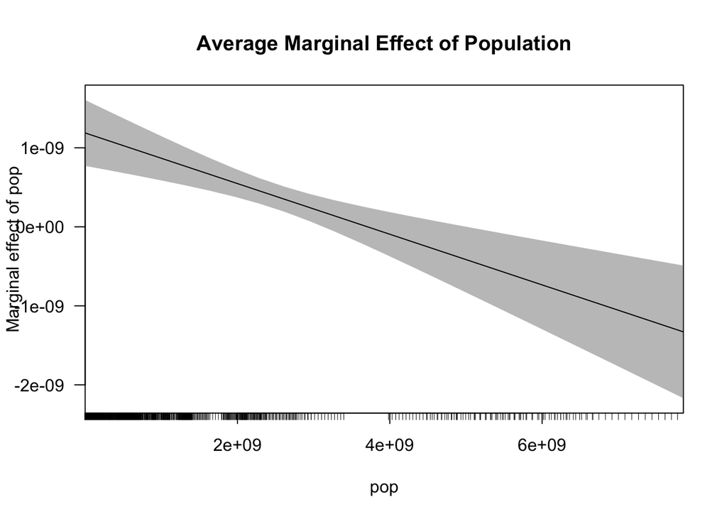

```r
cplot(int, "pop", what = "effect", main = "Average Marginal Effect of Population")
```

### Stargazer (Again)

Let’s show some models side by side

```r
library(stargazer)
knitr::opts_chunk$set(echo = TRUE, warning = FALSE)

stargazer(ols, re, fe, type = "html", column.labels = c("OLS", "RE", "FE"),
          model.names = FALSE, #remove model names
          dep.var.caption = "", #get rid of the dependent variable title at the top
          title = "Panel Data Results", #Have a title on your table
          covariate.labels = c("Edu", "lnPop", "Constant"), #rename variables to be cleaner
          omit = c("year"),  #omit the variables year from the output
         dep.var.labels   = "", #get rid of the dependent variable label
         model.numbers = FALSE, #g`et rid of model numbers
          add.lines=list(c("Time FE", "No", "Yes", "Yes")), # add a line/row for additional info (in this case about time fixed effects)
          notes= "Source: World Development Indicators Database", #add notes on the source of the data
          out = "panel_results.html" )#save the file in an output
```

```
##
## <table style="text-align:center"><caption><strong>Panel Data Results</strong></caption>
## <tr><td colspan="4" style="border-bottom: 1px solid black"></td></tr><tr><td style="text-align:left"></td><td colspan="3"></td></tr>
## <tr><td style="text-align:left"></td><td>OLS</td><td>RE</td><td>FE</td></tr>
## <tr><td colspan="4" style="border-bottom: 1px solid black"></td></tr><tr><td style="text-align:left">Edu</td><td>-0.045<sup>***</sup></td><td>-0.036<sup>***</sup></td><td>0.005</td></tr>
## <tr><td style="text-align:left"></td><td>(0.005)</td><td>(0.006)</td><td>(0.021)</td></tr>
## <tr><td style="text-align:left"></td><td></td><td></td><td></td></tr>
## <tr><td style="text-align:left">lnPop</td><td>-0.107<sup>*</sup></td><td>0.040</td><td>-3.237<sup>***</sup></td></tr>
## <tr><td style="text-align:left"></td><td>(0.057)</td><td>(0.076)</td><td>(1.198)</td></tr>
## <tr><td style="text-align:left"></td><td></td><td></td><td></td></tr>
## <tr><td style="text-align:left">Constant</td><td>8.484<sup>***</sup></td><td>6.933<sup>***</sup></td><td></td></tr>
## <tr><td style="text-align:left"></td><td>(1.092)</td><td>(1.439)</td><td></td></tr>
## <tr><td style="text-align:left"></td><td></td><td></td><td></td></tr>
## <tr><td colspan="4" style="border-bottom: 1px solid black"></td></tr><tr><td style="text-align:left">Time FE</td><td>No</td><td>Yes</td><td>Yes</td></tr>
## <tr><td style="text-align:left">Observations</td><td>1,766</td><td>1,766</td><td>1,766</td></tr>
## <tr><td style="text-align:left">R<sup>2</sup></td><td>0.047</td><td>0.382</td><td>0.385</td></tr>
## <tr><td style="text-align:left">Adjusted R<sup>2</sup></td><td>0.046</td><td>0.374</td><td>0.300</td></tr>
## <tr><td style="text-align:left">Residual Std. Error</td><td>4.212 (df = 1763)</td><td></td><td></td></tr>
## <tr><td style="text-align:left">F Statistic</td><td>43.624<sup>***</sup> (df = 2; 1763)</td><td>1,030.212<sup>***</sup></td><td>44.079<sup>***</sup> (df = 22; 1552)</td></tr>
## <tr><td colspan="4" style="border-bottom: 1px solid black"></td></tr><tr><td style="text-align:left"><em>Note:</em></td><td colspan="3" style="text-align:right"><sup>*</sup>p<0.1; <sup>**</sup>p<0.05; <sup>***</sup>p<0.01</td></tr>
## <tr><td style="text-align:left"></td><td colspan="3" style="text-align:right">Source: World Development Indicators Database</td></tr>
## </table>
```

Let’s see how we can only show covariates of interest so that our table is reasonable.

Here is the ugly table that you won’t show me because it’s unreasonable, right?

```r
knitr::opts_chunk$set(echo = TRUE, warning = FALSE)

#long version
fe_ols = lm(gdp~  edu + log(pop) +factor(country) +factor(year), data = wdi, na.action = na.omit)  ## Fixed effect(s)

fe_noyr <- plm(gdp ~ edu +log(pop) , data=wdi, index = c("iso2c"), model="within")
```

```r
# fe, fe_ols,fixed_tw are all different ways to produce the same exact results
stargazer(fe_noyr,fe, fe_ols, fixed_tw,
          type = "html",
          column.labels = c("one-way FE", "FE plm", "FE dummies", "FE plm"),
          model.names = FALSE,
          dep.var.caption = "",
          title = "Panel Data Results",
          omit = c("country", "year"),  #So, if we want to remove the fixed effects or estimates, we can use the option, omit (another way to do this is keep, but that has issues with the constant)
          covariate.labels = c("Edu", "lnPop", "Constant"),
          dep.var.labels   = "GDP per capita",
         add.lines=list(c("Time FE", "No", "Yes", "Yes", "Yes")),
          out = "panel_results_long.html")
```

```
##
## <table style="text-align:center"><caption><strong>Panel Data Results</strong></caption>
## <tr><td colspan="5" style="border-bottom: 1px solid black"></td></tr><tr><td style="text-align:left"></td><td colspan="4">GDP per capita</td></tr>
## <tr><td style="text-align:left"></td><td>one-way FE</td><td>FE plm</td><td>FE dummies</td><td>FE plm</td></tr>
## <tr><td style="text-align:left"></td><td>(1)</td><td>(2)</td><td>(3)</td><td>(4)</td></tr>
## <tr><td colspan="5" style="border-bottom: 1px solid black"></td></tr><tr><td style="text-align:left">Edu</td><td>-0.043<sup>*</sup></td><td>0.005</td><td>0.005</td><td>0.005</td></tr>
## <tr><td style="text-align:left"></td><td>(0.025)</td><td>(0.021)</td><td>(0.021)</td><td>(0.021)</td></tr>
## <tr><td style="text-align:left"></td><td></td><td></td><td></td><td></td></tr>
## <tr><td style="text-align:left">lnPop</td><td>-8.671<sup>***</sup></td><td>-3.237<sup>***</sup></td><td>-3.237<sup>***</sup></td><td>-3.237<sup>***</sup></td></tr>
## <tr><td style="text-align:left"></td><td>(1.288)</td><td>(1.198)</td><td>(1.198)</td><td>(1.198)</td></tr>
## <tr><td style="text-align:left"></td><td></td><td></td><td></td><td></td></tr>
## <tr><td style="text-align:left">Constant</td><td></td><td></td><td>60.138<sup>***</sup></td><td></td></tr>
## <tr><td style="text-align:left"></td><td></td><td></td><td>(20.637)</td><td></td></tr>
## <tr><td style="text-align:left"></td><td></td><td></td><td></td><td></td></tr>
## <tr><td colspan="5" style="border-bottom: 1px solid black"></td></tr><tr><td style="text-align:left">Time FE</td><td>No</td><td>Yes</td><td>Yes</td><td>Yes</td></tr>
## <tr><td style="text-align:left">Observations</td><td>1,766</td><td>1,766</td><td>1,766</td><td>1,766</td></tr>
## <tr><td style="text-align:left">R<sup>2</sup></td><td>0.049</td><td>0.385</td><td>0.538</td><td>0.005</td></tr>
## <tr><td style="text-align:left">Adjusted R<sup>2</sup></td><td>-0.068</td><td>0.300</td><td>0.475</td><td>-0.132</td></tr>
## <tr><td style="text-align:left">Residual Std. Error</td><td></td><td></td><td>3.126 (df = 1552)</td><td></td></tr>
## <tr><td style="text-align:left">F Statistic</td><td>40.501<sup>***</sup> (df = 2; 1572)</td><td>44.079<sup>***</sup> (df = 22; 1552)</td><td>8.488<sup>***</sup> (df = 213; 1552)</td><td>3.803<sup>**</sup> (df = 2; 1552)</td></tr>
## <tr><td colspan="5" style="border-bottom: 1px solid black"></td></tr><tr><td style="text-align:left"><em>Note:</em></td><td colspan="4" style="text-align:right"><sup>*</sup>p<0.1; <sup>**</sup>p<0.05; <sup>***</sup>p<0.01</td></tr>
## </table>
```

```r
#You can also use fixed est, but it doesn't play well with stargazer
fixed_est
```

```
## OLS estimation, Dep. Var.: gdp
## Observations: 1,766
## Fixed-effects: iso2c: 192,  year: 21
## Standard-errors: Clustered (iso2c)
##           Estimate Std. Error   t value Pr(>|t|)
## edu       0.005241   0.035786  0.146457  0.88372
## log(pop) -3.237291   2.141856 -1.511442  0.13233
## ---
## Signif. codes:  0 '***' 0.001 '**' 0.01 '*' 0.05 '.' 0.1 ' ' 1
## RMSE: 2.93022     Adj. R2: 0.474683
##                 Within R2: 0.004877
```

## Time-Series Regressions

### Lags and Leads

Lags and leads are pretty straightforward to add to an OLS model

```r
lagols <-  lm(gdp~ lfpart_f + log(pop) + lag(log(pop) , n=1) +lag(log(pop), n = 2), data = wdi)
summary(lagols)
```

```
##
## Call:
## lm(formula = gdp ~ lfpart_f + log(pop) + lag(log(pop), n = 1) +
##     lag(log(pop), n = 2), data = wdi)
##
## Residuals:
##     Min      1Q  Median      3Q     Max
## -57.506  -1.888   0.232   2.271  83.765
##
## Coefficients: (2 not defined because of singularities)
##                       Estimate Std. Error t value Pr(>|t|)
## (Intercept)          -0.162539   0.566714  -0.287   0.7743
## lfpart_f              0.014354   0.005051   2.842   0.0045 **
## log(pop)              0.175064   0.029452   5.944 2.98e-09 ***
## lag(log(pop), n = 1)        NA         NA      NA       NA
## lag(log(pop), n = 2)        NA         NA      NA       NA
## ---
## Signif. codes:  0 '***' 0.001 '**' 0.01 '*' 0.05 '.' 0.1 ' ' 1
##
## Residual standard error: 5.248 on 4838 degrees of freedom
##   (745 observations deleted due to missingness)
## Multiple R-squared:  0.008665,   Adjusted R-squared:  0.008255
## F-statistic: 21.14 on 2 and 4838 DF,  p-value: 7.203e-10
```

```r
lagplm <-plm(gdp~ lfpart_f + log(pop) + lag(log(pop) , n=1) +lag(log(pop), n = 2), data = wdi, index = c("iso2c" ,"year"), ignorena = TRUE)
summary(lagplm)
```

```
## Oneway (individual) effect Within Model
##
## Call:
## plm(formula = gdp ~ lfpart_f + log(pop) + lag(log(pop), n = 1) +
##     lag(log(pop), n = 2), data = wdi, index = c("iso2c", "year"),
##     ignorena = TRUE)
##
## Unbalanced Panel: n = 234, T = 3-20, N = 4613
##
## Residuals:
##      Min.   1st Qu.    Median   3rd Qu.      Max.
## -57.09148  -1.37308   0.43435   1.84931  88.13929
##
## Coefficients: (1 dropped because of singularities)
##                        Estimate Std. Error t-value  Pr(>|t|)
## lfpart_f               0.069462   0.027710  2.5068   0.01222 *
## log(pop)              68.654858   9.139609  7.5118 7.029e-14 ***
## lag(log(pop), n = 1) -76.770763   9.038073 -8.4942 < 2.2e-16 ***
## ---
## Signif. codes:  0 '***' 0.001 '**' 0.01 '*' 0.05 '.' 0.1 ' ' 1
##
## Total Sum of Squares:    107770
## Residual Sum of Squares: 101460
## R-Squared:      0.058543
## Adj. R-Squared: 0.0077696
## F-statistic: 90.7046 on 3 and 4376 DF, p-value: < 2.22e-16
```

Leads are similarly as easy….

```r
leadplm <-plm(gdp~ lfpart_f + log(pop) + lead(log(pop) , n=1) +lead(log(pop), n = 2), data = wdi, index = c("iso2c" ,"year"), ignorena = TRUE)
summary(leadplm)
```

```
## Oneway (individual) effect Within Model
##
## Call:
## plm(formula = gdp ~ lfpart_f + log(pop) + lead(log(pop), n = 1) +
##     lead(log(pop), n = 2), data = wdi, index = c("iso2c", "year"),
##     ignorena = TRUE)
##
## Unbalanced Panel: n = 234, T = 3-20, N = 4610
##
## Residuals:
##      Min.   1st Qu.    Median   3rd Qu.      Max.
## -49.40437  -1.33051   0.20818   1.58026  82.92163
##
## Coefficients: (1 dropped because of singularities)
##                          Estimate  Std. Error  t-value Pr(>|t|)
## lfpart_f                 0.020847    0.025288   0.8244   0.4098
## log(pop)              -106.219150    8.130817 -13.0638   <2e-16 ***
## lead(log(pop), n = 1)  102.697535    8.222666  12.4896   <2e-16 ***
## ---
## Signif. codes:  0 '***' 0.001 '**' 0.01 '*' 0.05 '.' 0.1 ' ' 1
##
## Total Sum of Squares:    86720
## Residual Sum of Squares: 82335
## R-Squared:      0.050568
## Adj. R-Squared: -0.00067075
## F-statistic: 77.6369 on 3 and 4373 DF, p-value: < 2.22e-16
```

### VAR

We will load our packages and then set the date column to a datetype so R knows that the column corresponds to a Date. It can be in any format, including quarters, so you just need to tell it what the format is. I have pulled this mostly for this [Towards Data Science blog] (https://towardsdatascience.com/a-deep-dive-on-vector-autoregression-in-r-58767ebb3f06). This [reference](https://www.econometrics-with-r.org/16.1-vector-autoregressions.html) may also be helpful.

```r
#loading all of the relevant packages
library(vars)
library(mFilter)
library(tseries)
library(TSstudio)
library(forecast)
library(vtable)
#getting VAR sample data
data <-read.csv("/Users/mkaltenberg/Documents/GitHub/Data_Analysis_Python_R/Advanced Regressions Stargazer/SampleVAR.csv")

#First, format the date column so R knows it's a date

data$date <- as.Date(data$date, format = "%m/%d/%y")
```

Next, you need to tell stata that the variables are time series and what frequency.

```r
#the data is quarterly, but the format of the date column is month day year. So, the frequency i 4.
gdp <- ts(data$real_gdp_growth, start = c(1999,2), frequency = 4)
psei <- ts(data$psei, start = c(1999,2), frequency = 4)
unem <- ts(data$unem, start = c(1999,2), frequency = 4)
bsp <- ts(data$bsp_rrp, start = c(1999,2), frequency = 4)

#We'll do this for each variable we want to follow over time
```

After declaring variables time series, you can do a lot of things much easier - run regressions or plot

```r
#pretty graphs
ts_plot(gdp)
```

[interactive chart not shown]

Next, we’ll bind the variables together to build our VAR model

```r
v1 <- cbind(gdp, bsp,psei, unem)
colnames(v1) <- cbind("GDP","BDP","PSEI", "UNEM")
```

Now, you need to figure out the number of lags

```r
lagselect <- VARselect(v1, lag.max = 15, type = "const")
```

And we estimate. Each equation represents an equation in the VAR system.

```r
Model1 <- VAR(v1, p = 2, type = "const", season = NULL, exog = NULL)
summary(Model1)
```

```
##
## VAR Estimation Results:
## =========================
## Endogenous variables: GDP, BDP, PSEI, UNEM
## Deterministic variables: const
## Sample size: 78
## Log Likelihood: -876.81
## Roots of the characteristic polynomial:
## 0.9776 0.8784  0.56 0.501 0.501 0.1641 0.1525 0.1525
## Call:
## VAR(y = v1, p = 2, type = "const", exogen = NULL)
##
##
## Estimation results for equation GDP:
## ====================================
## GDP = GDP.l1 + BDP.l1 + PSEI.l1 + UNEM.l1 + GDP.l2 + BDP.l2 + PSEI.l2 + UNEM.l2 + const
##
##           Estimate Std. Error t value Pr(>|t|)
## GDP.l1   0.7459223  0.1167482   6.389 1.67e-08 ***
## BDP.l1   0.0358778  0.2123106   0.169   0.8663
## PSEI.l1  0.0006419  0.0003791   1.693   0.0950 .
## UNEM.l1  0.0427137  0.1074861   0.397   0.6923
## GDP.l2  -0.2123565  0.1117912  -1.900   0.0617 .
## BDP.l2  -0.1287760  0.1994906  -0.646   0.5207
## PSEI.l2 -0.0005016  0.0003723  -1.347   0.1823
## UNEM.l2  0.0248510  0.1099687   0.226   0.8219
## const    1.8884962  1.2980986   1.455   0.1503
## ---
## Signif. codes:  0 '***' 0.001 '**' 0.01 '*' 0.05 '.' 0.1 ' ' 1
##
##
## Residual standard error: 1.168 on 69 degrees of freedom
## Multiple R-Squared: 0.6022,  Adjusted R-squared: 0.556
## F-statistic: 13.05 on 8 and 69 DF,  p-value: 2.899e-11
##
##
## Estimation results for equation BDP:
## ====================================
## BDP = GDP.l1 + BDP.l1 + PSEI.l1 + UNEM.l1 + GDP.l2 + BDP.l2 + PSEI.l2 + UNEM.l2 + const
##
```

[output cut: 64 more lines]

```
##
##
## Covariance matrix of residuals:
##           GDP       BDP       PSEI     UNEM
## GDP   1.36447   0.05253     47.093  0.14216
## BDP   0.05253   0.38329    -11.614 -0.02046
## PSEI 47.09273 -11.61410 133585.165 -3.63602
## UNEM  0.14216  -0.02046     -3.636  1.64637
##
## Correlation matrix of residuals:
##          GDP      BDP      PSEI      UNEM
## GDP  1.00000  0.07263  0.110304  0.094851
## BDP  0.07263  1.00000 -0.051327 -0.025761
## PSEI 0.11030 -0.05133  1.000000 -0.007753
## UNEM 0.09485 -0.02576 -0.007753  1.000000
```

You may want to do some testing, like for autocorrelation:

```r
Serial1 <- serial.test(Model1, lags.pt = 5, type = "PT.asymptotic")
Serial1
```

```
##
##  Portmanteau Test (asymptotic)
##
## data:  Residuals of VAR object Model1
## Chi-squared = 79.674, df = 48, p-value = 0.002751
```

Granger Causality tests

```r
Grangergdp<- causality(Model1, cause = "GDP")
Grangergdp
```

```
## $Granger
##
##  Granger causality H0: GDP do not Granger-cause BDP PSEI UNEM
##
## data:  VAR object Model1
## F-Test = 0.54534, df1 = 6, df2 = 276, p-value = 0.7735
##
##
## $Instant
##
##  H0: No instantaneous causality between: GDP and BDP PSEI UNEM
##
## data:  VAR object Model1
## Chi-squared = 2.1154, df = 3, p-value = 0.5488
```

```r
Grangerbdp<- causality(Model1, cause = "BDP")
Grangerbdp
```

```
## $Granger
##
##  Granger causality H0: BDP do not Granger-cause GDP PSEI UNEM
##
## data:  VAR object Model1
## F-Test = 0.87467, df1 = 6, df2 = 276, p-value = 0.5139
##
##
## $Instant
##
##  H0: No instantaneous causality between: BDP and GDP PSEI UNEM
##
## data:  VAR object Model1
## Chi-squared = 0.77145, df = 3, p-value = 0.8563
```

```r
Grangerpsei<- causality(Model1, cause = "PSEI")
Grangerpsei
```

```
## $Granger
##
##  Granger causality H0: PSEI do not Granger-cause GDP BDP UNEM
##
## data:  VAR object Model1
## F-Test = 2.5398, df1 = 6, df2 = 276, p-value = 0.02073
##
##
## $Instant
##
##  H0: No instantaneous causality between: PSEI and GDP BDP UNEM
##
## data:  VAR object Model1
## Chi-squared = 1.2372, df = 3, p-value = 0.7441
```

```r
Grangerunem<- causality(Model1, cause = "UNEM")
Grangerunem
```

```
## $Granger
##
##  Granger causality H0: UNEM do not Granger-cause GDP BDP PSEI
##
## data:  VAR object Model1
## F-Test = 1.0686, df1 = 6, df2 = 276, p-value = 0.3815
##
##
## $Instant
##
##  H0: No instantaneous causality between: UNEM and GDP BDP PSEI
##
## data:  VAR object Model1
## Chi-squared = 0.80907, df = 3, p-value = 0.8473
```

Impulse Response Functions

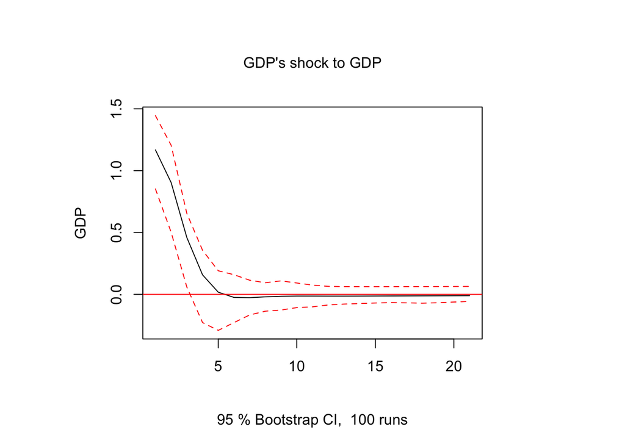

```r
GDPirf <- irf(Model1, impulse = "GDP", response = "GDP", n.ahead = 20, boot = TRUE)
plot(GDPirf, ylab = "GDP", main = "GDP's shock to GDP")
```

ACF and PACF Graphs

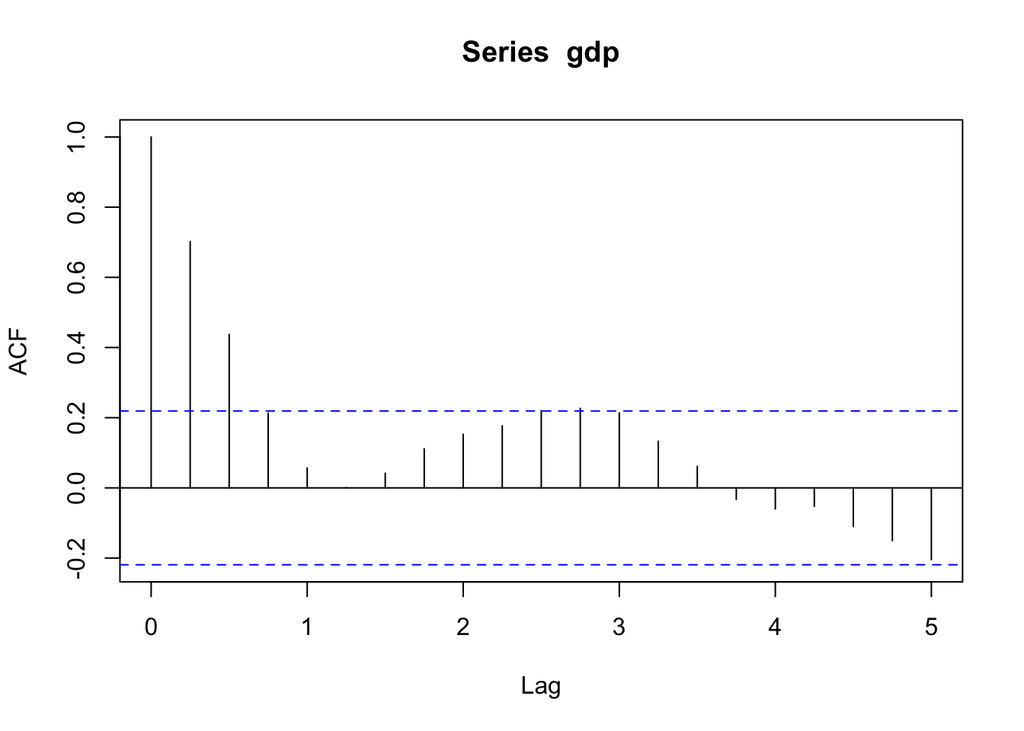

```r
acf (gdp, lag.max = 20, type = c("correlation", "covariance", "partial"), plot= TRUE,na.action = na.contiguous, demean = TRUE)
```

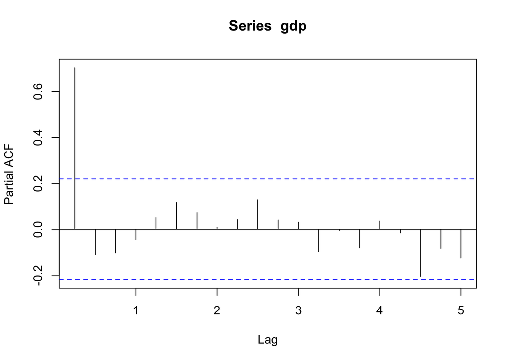

```r
pacf (gdp, lag.max = 20, plot = TRUE, na.action = na.contiguous)
```